# FitBit - Case Study

Table of Contents

# 1 INTRODUCTION

Urška Sršen and Sando Mur founded Bellabeat, a high-tech company that manufactures health-focused smart products. Sršen used her background as an artist to develop beautifully designed technology that informs and inspires women around the world. Collecting data on activity, sleep, stress, and reproductive health has allowed Bellabeat to empower women with knowledge about their own health and habits. Since it was founded in 2013, Bellabeat has grown rapidly and quickly positioned itself as a tech-driven wellness company for women.

By 2016, Bellabeat had opened offices around the world and launched multiple products. Bellabeat products became available through a growing number of online retailers in addition to their own e-commerce channel on [their website](http://bellabeat.com). The company has invested in traditional advertising media, such as radio, out-of-home billboards, print, and television, but focuses on digital marketing extensively. Bellabeat invests year-round in Google Search, maintaining active Facebook and Instagram pages, and consistently engages consumers on Twitter. Additionally, Bellabeat runs video ads on Youtube and display ads on the Google Display Network to support campaigns around key marketing dates.

[figure not shown]

[figure not shown]

# 2 ASK

I will examine data from FitBit users in this case study, which is a personal health tracker. The goal is to use FitBit secondary data to gather insights that will help BellaBeat, a different health tracker startup, make commercial decisions. BellaBeat’s marketing strategy, especially for two of its products, Leaf (tracker bracelet) and Time, can be guided by this data analysis. (wellness watch). By integrating with the BellaBeat app, their key function is the recording and measurement of user wellness activities. The software then offers users insights into their day-to-day wellness utilizing factors including sleep, weight, calories burned, menstrual cycle, and mindfulness practices. In order to identify the most significant issues BellaBeat may encounter and make suggestions for the tools to be used to address them, I will analyze FitBit data. Google Data Analytics, a course on Cursera created by Google, gave the datasets and some instructions. The datasets have some flaws and restrictions. Instead of ignoring these shortcomings and making it appear as though the analysis is faultless, the goal is to offer some potential solutions to get around them in the future. In reality, these constraints are present in a large number of comparable datasets. Therefore, it could be beneficial to go into detail about them.

Therefore, the objective at hand is essentially to offer BellaBeat advice on how to improve their digital marketing approach. The main strategy used in this case study to accomplish that goal is to carry out the following steps: first, create a scenario; second, determine what the stakeholders would be interested in; third, pre-determine some guiding questions; and finally, carry out a data analysis process to find answers that lead to the desired recommendations for the marketing team. The following steps are included in this analytical process: data preparation, data cleaning and processing, analysis, and visualization. There are sections and subsections in this case study. (refer to the table of content).

Following this overview, you can think of each component as one of the phases of data analysis (in the same order), which is what is typically done in practice. These steps are also known as gather information, prepare it for use, process it, communicate it, and take action. Each figure or table has a brief description of key findings below it.

**Deliverables**

1. A clear summary of the business task
2. A description of all data sources used
3. Documentation of any cleaning or manipulation of data
4. A summary of your analysis
5. Supporting visualizations and key findings
6. Your top high-level content recommendations based on your analysis

**Questions to address**

1. What are some trends in smart device usage?
2. How could these trends apply to BellaBeat customers?
3. How could these trends help influence BellaBeat marketing strategy?

# 3 PREPARE

## 3.1 Data set Source

The data source used for our case study is FitBit Fitness Tracker Data. This dataset is stored in Kaggle and was made available through Mobius.

## 3.2 Data Security

The website of BealaBeat has a comprehensive data privacy section. Additionally, as compared to its rivals, it appears to be well developed. At first appearance, it appears that BellaBeat can gather useful information from its users and create marketing plans based on the information users offer, all without disclosing their identities or selling to other businesses. To determine the veracity of these assumptions, more research is required. I’ll leave everything up to the reader and include any relevant links in the References section.

# 4 PROCESS

## 4.1 Loading Data

```r
library(tidyverse)
library(tidymodels)
library(lubridate)
library(janitor)
library(ggrepel)
library(skimr)
library(kableExtra)
library(readr)
library(lubridate)
library(openair)
library(psych)
library(DataExplorer)
library(ggpubr)
library(here)
library(formattable)
library(scales)
library(dygraphs)
library(xts)
library(GGally)
```

Let’s install our data:

```r
setwd("C:/Users/cemil/Desktop/Case Study/FitBit DataSet/Fitabase Data 4.12.16-5.12.16")
daily_activity<-read_csv("C:/Users/cemil/Desktop/Case Study/FitBit DataSet/Fitabase Data 4.12.16-5.12.16/dailyActivity_merged.csv")
daily_calories<-read_csv("C:/Users/cemil/Desktop/Case Study/FitBit DataSet/Fitabase Data 4.12.16-5.12.16/dailyCalories_merged.csv")
daily_intensities<-read_csv("C:/Users/cemil/Desktop/Case Study/FitBit DataSet/Fitabase Data 4.12.16-5.12.16/dailyIntensities_merged.csv")
weightloginfo<-read_csv("C:/Users/cemil/Desktop/Case Study/FitBit DataSet/Fitabase Data 4.12.16-5.12.16/weightLogInfo_merged.csv")
daily_steps<-read_csv("C:/Users/cemil/Desktop/Case Study/FitBit DataSet/Fitabase Data 4.12.16-5.12.16/dailySteps_merged.csv")
hourly_calories<-read_csv("C:/Users/cemil/Desktop/Case Study/FitBit DataSet/Fitabase Data 4.12.16-5.12.16/hourlyCalories_merged.csv")
hourly_intensities<-read_csv("C:/Users/cemil/Desktop/Case Study/FitBit DataSet/Fitabase Data 4.12.16-5.12.16/hourlyIntensities_merged.csv")
hourly_steps<-read_csv("C:/Users/cemil/Desktop/Case Study/FitBit DataSet/Fitabase Data 4.12.16-5.12.16/hourlySteps_merged.csv")
heartrate_seconds<-read_csv("C:/Users/cemil/Desktop/Case Study/FitBit DataSet/Fitabase Data 4.12.16-5.12.16/heartrate_seconds_merged.csv")
daily_sleep<-read_csv("C:/Users/cemil/Desktop/Case Study/FitBit DataSet/Fitabase Data 4.12.16-5.12.16/sleepDay_merged.csv")
minute_mets<-read_csv("C:/Users/cemil/Desktop/Case Study/FitBit DataSet/Fitabase Data 4.12.16-5.12.16/minuteMETsNarrow_merged.csv")
```

```r
#Gathering all datas in a list to analyse all in once:

df_list<-list(daily_activity,daily_calories,daily_intensities,daily_sleep,daily_steps,hourly_calories,hourly_intensities,hourly_steps,weightloginfo,heartrate_seconds,minute_mets)
```

```r
#Finding distinct_id values

Distinct_id<-df_list |> map(c(1)) |> map_int(n_distinct)

#Finding missing rows

Missing_row <-df_list |>  map_int(n_missing)

#Finding duplicated values

Duplicated_Values<-vector(length = length(df_list))
for(i in 1:length(df_list)){
  Duplicated_Values[i]=sum(duplicated(df_list[[i]]))
}


uniq<-data.frame(c("daily_activity","daily_calories","daily_intensities","daily_sleep","daily_steps","hourly_calories","hourly_intensities","hourly_steps","weightloginfo","heartrate_seconds","minute_mets"),Distinct_id,Missing_row,Duplicated_Values)
uniq<-uniq%>% rename(Data_set=colnames(uniq[1]))%>%arrange(-Distinct_id)

kbl(uniq, escape = F) %>%
  kable_paper("hover", full_width = F)
```

| Data_set | Distinct_id | Missing_row | Duplicated_Values |
| --- | --- | --- | --- |
| daily_activity | 33 | 0 | 0 |
| daily_calories | 33 | 0 | 0 |
| daily_intensities | 33 | 0 | 0 |
| daily_steps | 33 | 0 | 0 |
| hourly_calories | 33 | 0 | 0 |
| hourly_intensities | 33 | 0 | 0 |
| hourly_steps | 33 | 0 | 0 |
| minute_mets | 33 | 0 | 0 |
| daily_sleep | 24 | 0 | 3 |
| heartrate_seconds | 14 | 0 | 0 |
| weightloginfo | 8 | 65 | 0 |

```r
#Removing duplicated values in daily_sleep

daily_sleep<-distinct(daily_sleep)
```

We can select below data frames since there are some missing Ids on other dataframes:

- daily_activity
- daily_calories
- Daily_intensities
- Daily_steps
- hourly_steps
- hourly_calories
- hourly_intensities
- minute_mets

## 4.2 Inpsecting and Validating The Data Sets

```r
head(daily_activity,5)
```

```
## # A tibble: 5 × 15
##           Id ActivityDate TotalSteps TotalDistance TrackerDistance
##        <dbl> <chr>             <dbl>         <dbl>           <dbl>
## 1 1503960366 4/12/2016         13162          8.5             8.5
## 2 1503960366 4/13/2016         10735          6.97            6.97
## 3 1503960366 4/14/2016         10460          6.74            6.74
## 4 1503960366 4/15/2016          9762          6.28            6.28
## 5 1503960366 4/16/2016         12669          8.16            8.16
## # ℹ 10 more variables: LoggedActivitiesDistance <dbl>,
## #   VeryActiveDistance <dbl>, ModeratelyActiveDistance <dbl>,
## #   LightActiveDistance <dbl>, SedentaryActiveDistance <dbl>,
## #   VeryActiveMinutes <dbl>, FairlyActiveMinutes <dbl>,
## #   LightlyActiveMinutes <dbl>, SedentaryMinutes <dbl>, Calories <dbl>
```

```r
str(daily_activity)
```

```
## spc_tbl_ [940 × 15] (S3: spec_tbl_df/tbl_df/tbl/data.frame)
##  $ Id                      : num [1:940] 1.5e+09 1.5e+09 1.5e+09 1.5e+09 1.5e+09 ...
##  $ ActivityDate            : chr [1:940] "4/12/2016" "4/13/2016" "4/14/2016" "4/15/2016" ...
##  $ TotalSteps              : num [1:940] 13162 10735 10460 9762 12669 ...
##  $ TotalDistance           : num [1:940] 8.5 6.97 6.74 6.28 8.16 ...
##  $ TrackerDistance         : num [1:940] 8.5 6.97 6.74 6.28 8.16 ...
##  $ LoggedActivitiesDistance: num [1:940] 0 0 0 0 0 0 0 0 0 0 ...
##  $ VeryActiveDistance      : num [1:940] 1.88 1.57 2.44 2.14 2.71 ...
##  $ ModeratelyActiveDistance: num [1:940] 0.55 0.69 0.4 1.26 0.41 ...
##  $ LightActiveDistance     : num [1:940] 6.06 4.71 3.91 2.83 5.04 ...
##  $ SedentaryActiveDistance : num [1:940] 0 0 0 0 0 0 0 0 0 0 ...
##  $ VeryActiveMinutes       : num [1:940] 25 21 30 29 36 38 42 50 28 19 ...
##  $ FairlyActiveMinutes     : num [1:940] 13 19 11 34 10 20 16 31 12 8 ...
##  $ LightlyActiveMinutes    : num [1:940] 328 217 181 209 221 164 233 264 205 211 ...
##  $ SedentaryMinutes        : num [1:940] 728 776 1218 726 773 ...
##  $ Calories                : num [1:940] 1985 1797 1776 1745 1863 ...
##  - attr(*, "spec")=
##   .. cols(
##   ..   Id = col_double(),
##   ..   ActivityDate = col_character(),
##   ..   TotalSteps = col_double(),
##   ..   TotalDistance = col_double(),
##   ..   TrackerDistance = col_double(),
##   ..   LoggedActivitiesDistance = col_double(),
##   ..   VeryActiveDistance = col_double(),
##   ..   ModeratelyActiveDistance = col_double(),
##   ..   LightActiveDistance = col_double(),
##   ..   SedentaryActiveDistance = col_double(),
##   ..   VeryActiveMinutes = col_double(),
##   ..   FairlyActiveMinutes = col_double(),
##   ..   LightlyActiveMinutes = col_double(),
##   ..   SedentaryMinutes = col_double(),
##   ..   Calories = col_double()
##   .. )
##  - attr(*, "problems")=<externalptr>
```

```r
head(daily_calories,5)
```

```
## # A tibble: 5 × 3
##           Id ActivityDay Calories
##        <dbl> <chr>          <dbl>
## 1 1503960366 4/12/2016       1985
## 2 1503960366 4/13/2016       1797
## 3 1503960366 4/14/2016       1776
## 4 1503960366 4/15/2016       1745
## 5 1503960366 4/16/2016       1863
```

```r
str(daily_calories)
```

```
## spc_tbl_ [940 × 3] (S3: spec_tbl_df/tbl_df/tbl/data.frame)
##  $ Id         : num [1:940] 1.5e+09 1.5e+09 1.5e+09 1.5e+09 1.5e+09 ...
##  $ ActivityDay: chr [1:940] "4/12/2016" "4/13/2016" "4/14/2016" "4/15/2016" ...
##  $ Calories   : num [1:940] 1985 1797 1776 1745 1863 ...
##  - attr(*, "spec")=
##   .. cols(
##   ..   Id = col_double(),
##   ..   ActivityDay = col_character(),
##   ..   Calories = col_double()
##   .. )
##  - attr(*, "problems")=<externalptr>
```

```r
head(daily_intensities,5)
```

```
## # A tibble: 5 × 10
##         Id ActivityDay SedentaryMinutes LightlyActiveMinutes FairlyActiveMinutes
##      <dbl> <chr>                  <dbl>                <dbl>               <dbl>
## 1   1.50e9 4/12/2016                728                  328                  13
## 2   1.50e9 4/13/2016                776                  217                  19
## 3   1.50e9 4/14/2016               1218                  181                  11
## 4   1.50e9 4/15/2016                726                  209                  34
## 5   1.50e9 4/16/2016                773                  221                  10
## # ℹ 5 more variables: VeryActiveMinutes <dbl>, SedentaryActiveDistance <dbl>,
## #   LightActiveDistance <dbl>, ModeratelyActiveDistance <dbl>,
## #   VeryActiveDistance <dbl>
```

```r
str(daily_intensities)
```

```
## spc_tbl_ [940 × 10] (S3: spec_tbl_df/tbl_df/tbl/data.frame)
##  $ Id                      : num [1:940] 1.5e+09 1.5e+09 1.5e+09 1.5e+09 1.5e+09 ...
##  $ ActivityDay             : chr [1:940] "4/12/2016" "4/13/2016" "4/14/2016" "4/15/2016" ...
##  $ SedentaryMinutes        : num [1:940] 728 776 1218 726 773 ...
##  $ LightlyActiveMinutes    : num [1:940] 328 217 181 209 221 164 233 264 205 211 ...
##  $ FairlyActiveMinutes     : num [1:940] 13 19 11 34 10 20 16 31 12 8 ...
##  $ VeryActiveMinutes       : num [1:940] 25 21 30 29 36 38 42 50 28 19 ...
##  $ SedentaryActiveDistance : num [1:940] 0 0 0 0 0 0 0 0 0 0 ...
##  $ LightActiveDistance     : num [1:940] 6.06 4.71 3.91 2.83 5.04 ...
##  $ ModeratelyActiveDistance: num [1:940] 0.55 0.69 0.4 1.26 0.41 ...
##  $ VeryActiveDistance      : num [1:940] 1.88 1.57 2.44 2.14 2.71 ...
##  - attr(*, "spec")=
##   .. cols(
##   ..   Id = col_double(),
##   ..   ActivityDay = col_character(),
##   ..   SedentaryMinutes = col_double(),
##   ..   LightlyActiveMinutes = col_double(),
##   ..   FairlyActiveMinutes = col_double(),
##   ..   VeryActiveMinutes = col_double(),
##   ..   SedentaryActiveDistance = col_double(),
##   ..   LightActiveDistance = col_double(),
##   ..   ModeratelyActiveDistance = col_double(),
##   ..   VeryActiveDistance = col_double()
##   .. )
##  - attr(*, "problems")=<externalptr>
```

```r
head(daily_steps,5)
```

```
## # A tibble: 5 × 3
##           Id ActivityDay StepTotal
##        <dbl> <chr>           <dbl>
## 1 1503960366 4/12/2016       13162
## 2 1503960366 4/13/2016       10735
## 3 1503960366 4/14/2016       10460
## 4 1503960366 4/15/2016        9762
## 5 1503960366 4/16/2016       12669
```

```r
str(daily_steps)
```

```
## spc_tbl_ [940 × 3] (S3: spec_tbl_df/tbl_df/tbl/data.frame)
##  $ Id         : num [1:940] 1.5e+09 1.5e+09 1.5e+09 1.5e+09 1.5e+09 ...
##  $ ActivityDay: chr [1:940] "4/12/2016" "4/13/2016" "4/14/2016" "4/15/2016" ...
##  $ StepTotal  : num [1:940] 13162 10735 10460 9762 12669 ...
##  - attr(*, "spec")=
##   .. cols(
##   ..   Id = col_double(),
##   ..   ActivityDay = col_character(),
##   ..   StepTotal = col_double()
##   .. )
##  - attr(*, "problems")=<externalptr>
```

According to data-sets, we can select the primary key as **Id** variable.

## 4.3 Data Cleaning and Transformations

As we look to the data types of each variable, we need to convert dates as date format.

```r
daily_activity<-daily_activity %>% mutate(ActivityDate=mdy(ActivityDate)) %>% mutate(weekday=wday(ActivityDate,abbr = FALSE, label=TRUE, locale = "EN"))
daily_calories<-daily_calories %>% mutate(ActivityDay=mdy(ActivityDay))%>% mutate(weekday=wday(ActivityDay,abbr = FALSE, label=TRUE, locale = "EN"))
daily_intensities<-daily_intensities %>% mutate(ActivityDay=mdy(ActivityDay))%>%mutate(weekday=wday(ActivityDay,abbr = FALSE, label=TRUE, locale = "EN"))
daily_sleep<-daily_sleep %>% mutate(SleepDay=mdy_hms(SleepDay)) %>% mutate(weekday=wday(SleepDay,abbr = FALSE, label=TRUE, locale = "EN"))
daily_steps<-daily_steps %>% mutate(ActivityDay=mdy(ActivityDay)) %>% mutate(weekday=wday(ActivityDay,abbr = FALSE, label=TRUE, locale = "EN"))

hourly_calories<-hourly_calories %>% mutate(ActivityHour=mdy_hms(ActivityHour)) %>% mutate(Hour=hour(ActivityHour),weekday=wday(ActivityHour, abbr = FALSE, label=TRUE, locale = "EN"))
hourly_intensities<-hourly_intensities %>% mutate(ActivityHour=mdy_hms(ActivityHour)) %>% mutate(Hour=hour(ActivityHour),weekday=wday(ActivityHour,,abbr = FALSE, label=TRUE, locale = "EN"))
hourly_steps<-hourly_steps %>% mutate(ActivityHour=mdy_hms(ActivityHour)) %>% mutate(Hour=hour(ActivityHour),weekday=wday(ActivityHour, abbr = FALSE,label=TRUE, locale = "EN"))
heartrate_seconds<-heartrate_seconds %>% mutate(Time=mdy_hms(Time)) %>% mutate(Hour=hour(Time),weekday=wday(Time,abbr = FALSE, label=TRUE, locale = "EN"))

daily_mets<-minute_mets |> mutate(ActivityMinute=mdy_hms(ActivityMinute)) |> mutate(ActivityMinute=date(ActivityMinute))|>  mutate(weekday=wday(ActivityMinute,abbr = FALSE, label=TRUE, locale = "EN")) |> rename(date=ActivityMinute) |>
  group_by(Id,date) |> summarise(average_daily_mets=round(mean(METs),digits = 0), .groups = "keep")

hourly_mets<-minute_mets |> mutate(ActivityMinute=mdy_hms(ActivityMinute))|> mutate(ActivityMinute=date(ActivityMinute)) |> mutate(hour=hour(ActivityMinute))|>  mutate(weekday=wday(ActivityMinute,abbr = FALSE, label=TRUE, locale = "EN")) |> rename(date=ActivityMinute) |>
  group_by(Id,,date,hour) |> summarise(average_hourly_mets=round(mean(METs),digits = 0), .groups = "keep")
#Also we can name the all date columns with same name to make the merging process easy.

daily_activity <-daily_activity |> rename(date=ActivityDate)
daily_calories<-daily_calories |> rename(date=ActivityDay)
daily_intensities<-daily_intensities |> rename(date=ActivityDay)
daily_sleep<-daily_sleep |> rename(date=SleepDay)
daily_steps<-daily_steps |> rename(date=ActivityDay)
```

```r
dt<- daily_steps[1:5,]
dt
```

```
## # A tibble: 5 × 4
##           Id date       StepTotal weekday
##        <dbl> <date>         <dbl> <ord>
## 1 1503960366 2016-04-12     13162 Tuesday
## 2 1503960366 2016-04-13     10735 Wednesday
## 3 1503960366 2016-04-14     10460 Thursday
## 4 1503960366 2016-04-15      9762 Friday
## 5 1503960366 2016-04-16     12669 Saturday
```

# 5 ANALYSE

When we look at the data frames of daily activity and daily intesities, they have identical column names. Let’s check if these columns are totally has same values (observations). If the answer is yes, we can merge these two datasets with leaving this columns same.

```r
intersect_daily_activity_intensties<- intersect(colnames(daily_activity),colnames(daily_intensities))
intersect_daily_calories<-intersect(colnames(daily_activity),colnames(daily_calories))

daily_steps<-daily_steps |> rename(TotalSteps=StepTotal)
intersect_daily_steps<-intersect(colnames(daily_activity),colnames(daily_steps))

intersect_daily_activity_intensties
```

```
##  [1] "Id"                       "date"
##  [3] "VeryActiveDistance"       "ModeratelyActiveDistance"
##  [5] "LightActiveDistance"      "SedentaryActiveDistance"
##  [7] "VeryActiveMinutes"        "FairlyActiveMinutes"
##  [9] "LightlyActiveMinutes"     "SedentaryMinutes"
## [11] "weekday"
```

```r
intersect_daily_calories
```

```
## [1] "Id"       "date"     "Calories" "weekday"
```

```r
#Let's select the identical columns from both data frame
 sc_daily_activity<-daily_activity |> select(intersect_daily_activity_intensties)
 sc_daily_intensities<-daily_intensities |> select(intersect_daily_activity_intensties)

 sc_daily_calories<-daily_calories |> select(intersect_daily_calories)
 sc_daily_activity_calories<-daily_activity |> select(intersect_daily_calories)
 sc_daily_steps<-daily_steps |> select(intersect_daily_steps)
 sc_daily_activity_steps<-daily_activity |> select(intersect_daily_steps)




 # Let's see if the all identical cols has exactly same. (including the values)

 identical(sc_daily_activity,sc_daily_intensities)
```

```
## [1] TRUE
```

```r
 identical(sc_daily_activity_calories,sc_daily_calories)
```

```
## [1] TRUE
```

```r
 identical(sc_daily_steps,sc_daily_activity_steps)
```

```
## [1] TRUE
```

Since the all columns of daily_intensities, daily_calories and daily_steps are exist in daily_activity we can use daily_activity data set instead of using these data frames. We can group and merge the datas as daily and hourly.

In addition I catagorised the activit level according to total daily steps.[(source)](https://www.10000steps.org.au/articles/healthy-lifestyles/counting-steps/)

```r
daily_combined_data<-daily_activity |> left_join(daily_sleep, by=c("Id","date","weekday")) |> left_join(daily_mets, by=c("Id","date"))

daily_combined_data<-daily_combined_data |> mutate(activity_level=case_when(
  TotalSteps < 5000 ~ "Sedentary",
  TotalSteps >= 5000 & TotalSteps<7500 ~ "LightlyActive",
  TotalSteps>=7500 & TotalSteps<10000~ "ModerateActive",
  TotalSteps>=10000 & TotalSteps <12500~ "Active",
  TotalSteps>=12500~ "VeryActive"
))
 activity_level<-c("Sedentary","LightlyActive" ,"ModerateActive","Active","VeryActive")
daily_combined_data$activity_level<-factor(daily_combined_data$activity_level,levels = activity_level)
hourly_combined0 <- hourly_calories |> left_join(hourly_intensities, by=c("Id","ActivityHour","Hour","weekday"))
hourly_combined_data <- hourly_combined0 |> left_join(hourly_steps,by=c("Id","ActivityHour","Hour","weekday"))
```

# 6 SHARE

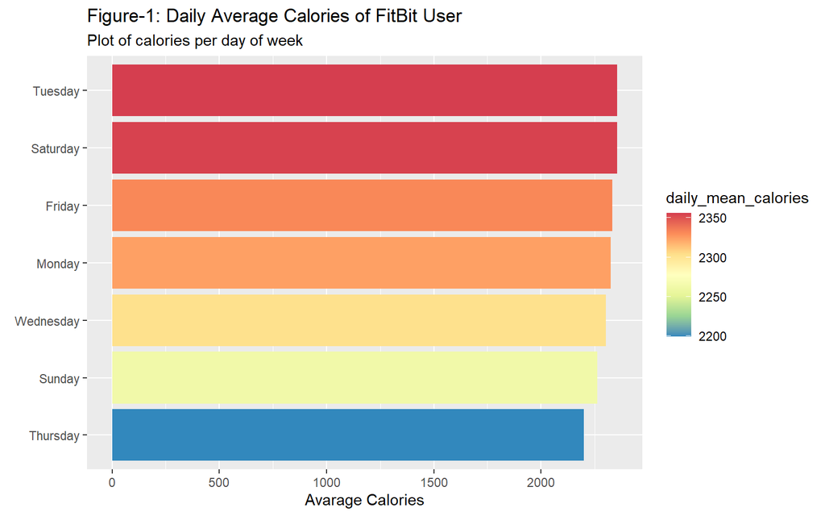

| Insights | Conclusions |
| --- | --- |
| Insight 1 | The users are the most active on Saturday and Tuesday. |
| Insight 2 | The users is tend to rest or stay passive mostly on Thursday and Sunday. |

[interactive chart not shown]

| Insights | Conclusions |
| --- | --- |
| Insight 1 | Mostly the burnt calories are increasing with the steps, there is an positive realationship. |
| Insight 2 | The peak days for calories and steps are generally observed Saturdays. |
| Insight 3 | Some data are missing for the last day of the data set (12/05/2016). |

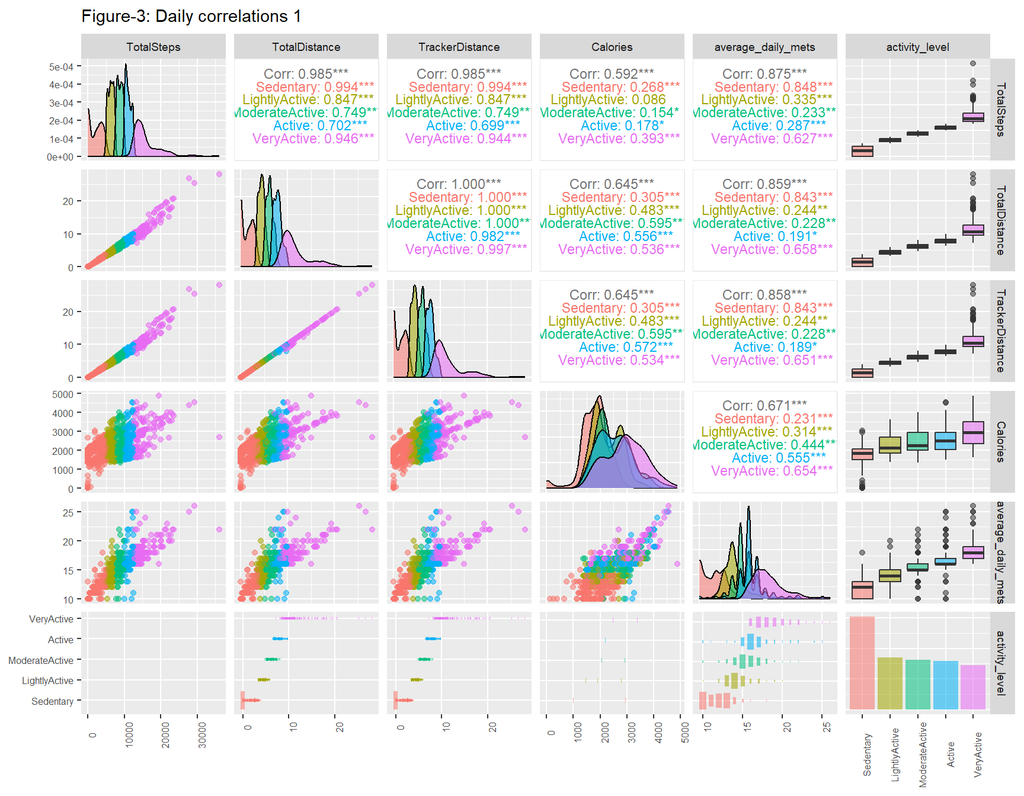

[output not shown]

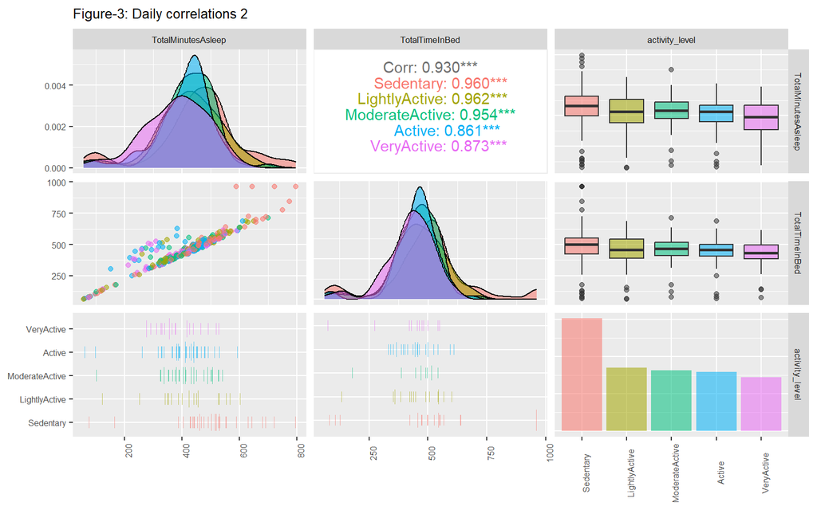

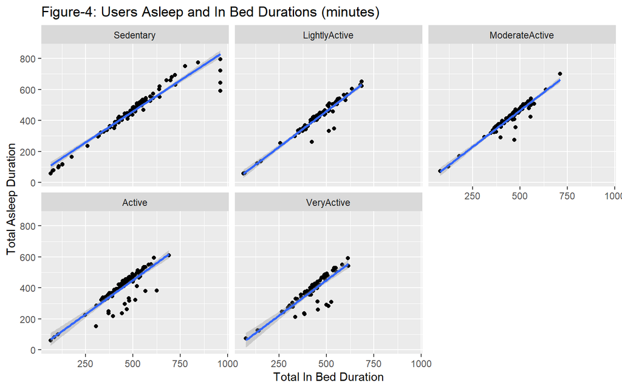

[output not shown]

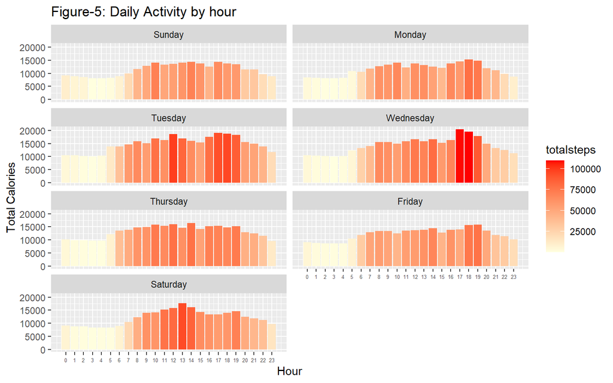

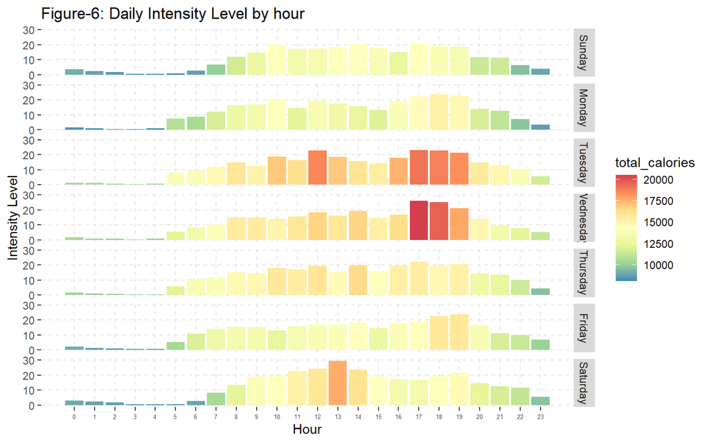

| Insights | Conclusions |
| --- | --- |
| Insight 1 | The majority of activity peak times lie between 5:00 and 8:00 p.m. . |
| Insight 2 | The peak hour for Saturday is 1:30 p.m.. |
| Insight 3 | For the workdays, users are tend to burn more calories on wednesday between 5:00 and 6:00 p.m.. |

# 7 ACT

> Motivating Sedentary users with showing the useful outcomes from very active users
- Fitbit can send notifications a brief summary statistics of very active users to encourage sedentary users.
- Some users may not choose the wear devices during the sleep time since some users are missing in sleep data so fitbit can develop some feature that integrate device which can track the snoring which pushes users to wear the devices during the sleeping period.
- Fitbit can integrate the user with other users to compare their activity with other users and see the which is the mean data for each acitivy group. (sedantary,moderate, active…etc. )

> Developing the data collection methodology
- Most of the users’ BMI index, weight..etc information is missing. Fitbit can develop customised training programs for each level according to user’s BMI index and engage the users enter this information to earn the customised training program.
- In addition, it is obvious that heartrate data is missing for some users, there can be mainly two reason of this if it is not recieved from the device
  - Some users’ can turn off the heart rate sensor or not allow to track the hear rate. In this case, users should be informed how this information can be critical to track their health and it can be used for customised training program.
  - Heart rate sensor may not be work correctly. In this case, sensitivity of the sensor should be fixed and also users should be informed the correct way using the accessories.

# 8 REFERANCES

**The data set can be found on Kaggle:**

Kaggle dataset link: https://www.kaggle.com/arashnic/fitbit

**The data privacy information can be found:**

BellaBeat’s privacy policy: https://bellabeat.com/privacy-policy/